# Milestone Report

Vicente Garcia

2022-08-27

## Introduction

The main goal of this report is to show the EDA performed on the three English datasets named blogs, news, and Twitter. The report is organized as follows: Section 1, we load each dataset and summarize the line counts. In section 2, we applied basic processing and created the training sets. Finally, in Section 3, shows an EDA for each training dataset.

First, we load some valuable libraries for this report.

```r
library(NLP)
library(tm)
library(stringi)
#library(SnowballC)
#library(RColorBrewer)
library(wordcloud)
library(ggplot2)
#library(textclean)
```

## 1. Loading the datasets

As the capstone file containing all the datasets is big, we have previously downloaded and unzipped it. Therefore, we have omitted the downloading instructions in this section, using only the loading code for the three datasets with the txt extension.

```r
options(warn=-1)
con = file("en_US.blogs.txt", "r")
linblogs =readLines(con)
con = file("en_US.news.txt", "r")
linnews =readLines(con)
con = file("en_US.twitter.txt", "r")
lintwitter =readLines(con)
close(con)
```

Some basic statistics on the original datasets

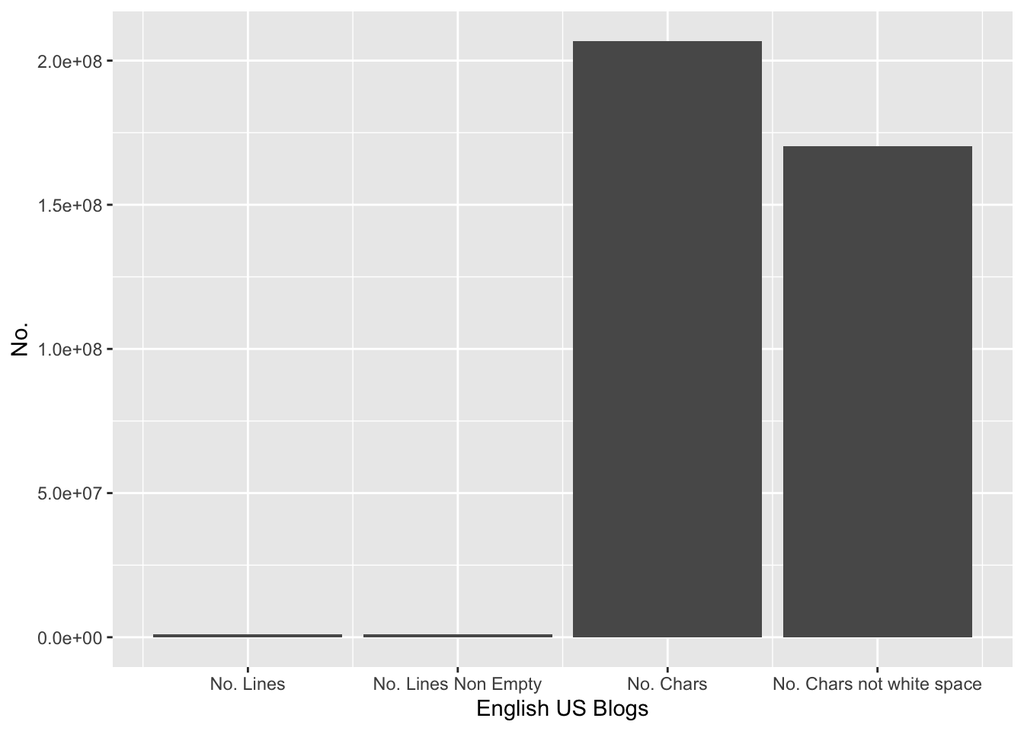

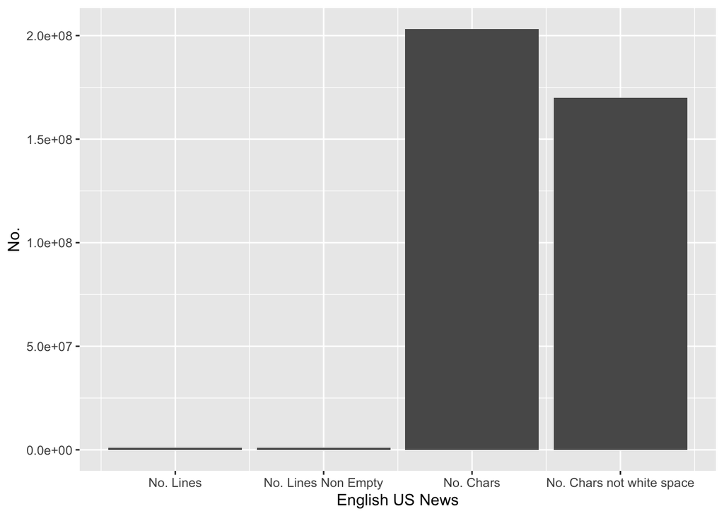

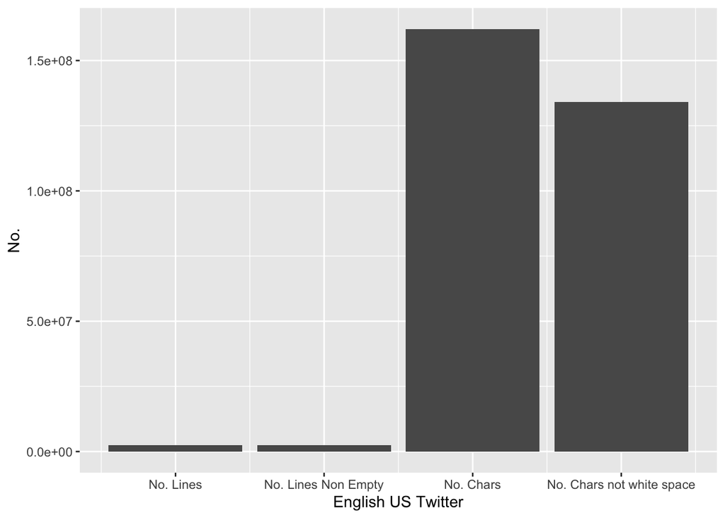

## Data Splitting for out-of-sample construction and evaluation

```r
linblogs <-sample(linblogs, length(linblogs)*0.30)
linnews <-sample(linnews, length(linnews)*0.30)
lintwitter <-sample(lintwitter, length(lintwitter)*0.30)
print(length(linblogs))
```

```
## [1] 269786
```

```r
print(length(linnews))
```

```
## [1] 303072
```

```r
print(length(lintwitter))
```

```
## [1] 708044
```

## Basic Processing

We perform some preprocessing on each dataset for removing hashs, url, puntuation, stopwords and spaces.

```r
lintwitter <- tolower(lintwitter)
lintwitter <- gsub("@\\w+", "", lintwitter)
lintwitter <- gsub("https?://.+", "", lintwitter)
lintwitter <- gsub("\\d+\\w*\\d*", "", lintwitter)
lintwitter <- gsub("#\\w+", "", lintwitter)
lintwitter <- gsub("[^\x01-\x7F]", "", lintwitter)
lintwitter <- gsub("[[:punct:]]", " ", lintwitter)

lintwitter <- gsub("\n", " ", lintwitter)
lintwitter <- gsub("^\\s+", "", lintwitter)
lintwitter <- gsub("\\s+$", "", lintwitter)
lintwitter <- gsub("[ |\t]+", " ", lintwitter)

lintwitter <- Corpus(VectorSource(lintwitter))
lintwitter <- tm_map(lintwitter,removePunctuation)
lintwitter <- tm_map(lintwitter,removeWords, stopwords("english"))
lintwitter <- tm_map(lintwitter,stripWhitespace)
```

The previous preprocessing steps also are applied to US-Blogs and US-News training datasets. However, for the sake of clarity, we hide the code.

## Exploratory Data Analysis

For each dataset, we plot a bar with the 20 most frequent words. We can observe that some words have a length of 3 characters. In the future, this word could be removed from the corpus.

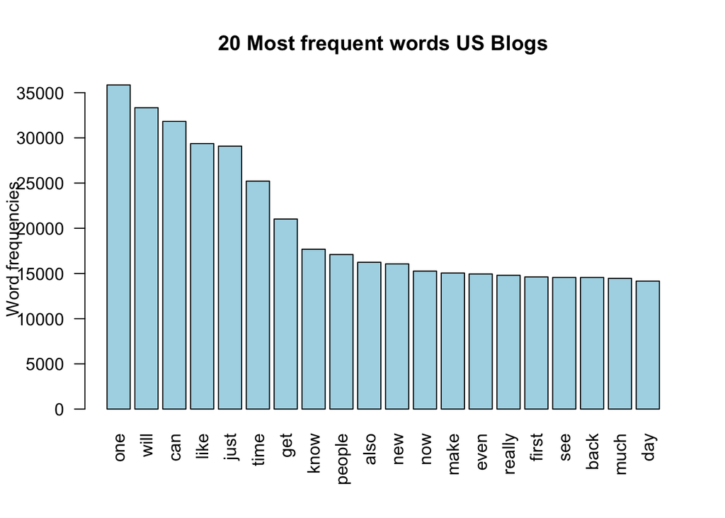

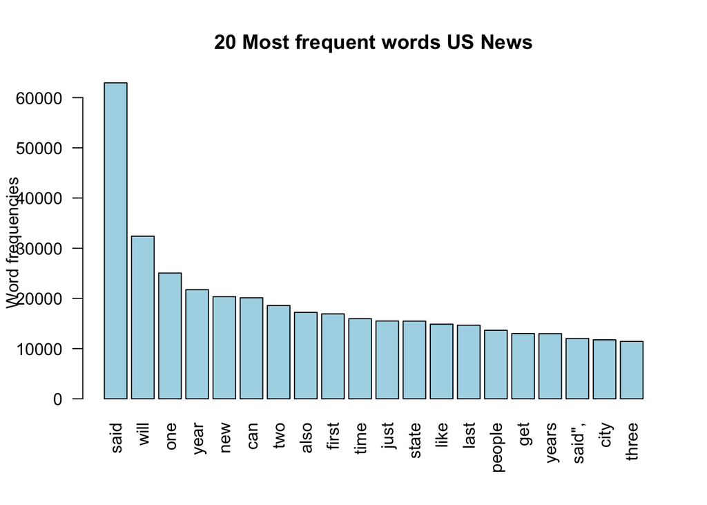

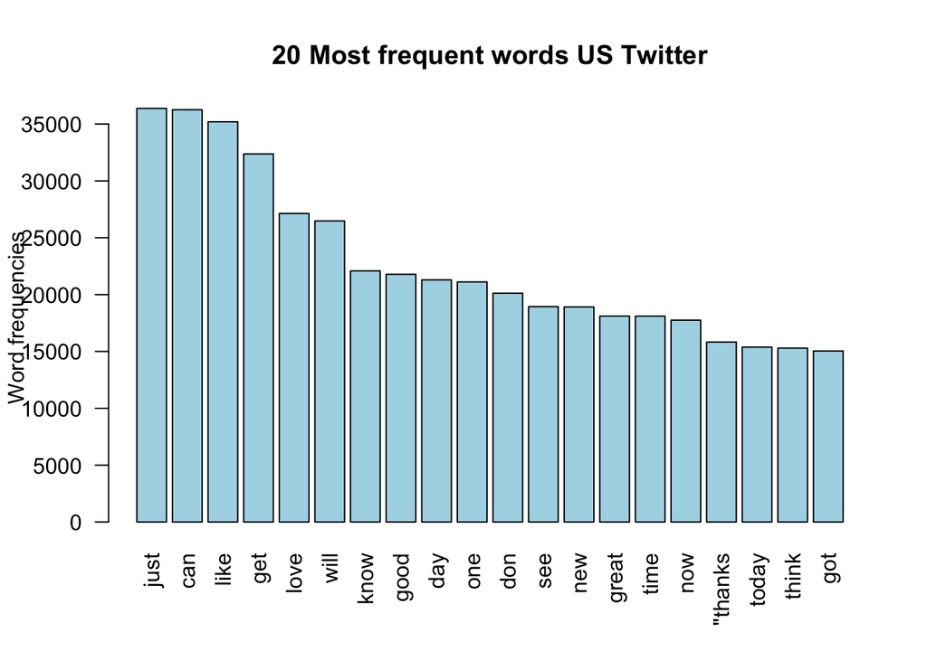

## Plans for creating the prediction algorithm and the shiny app

We believe that for building a prediction algorithm, some words with a length less than 5 characters should be remove. Besides, several prediction algorithms should be evaluated in order to get the best performance prediction algorithm.

The shiny app should be capable to predict the sentences more used. It will be an single app but with a high performance to predict the sentence.